# Generalized Linear Models for Binary Data

Me

05/04/2021

## Admitting to the graduate school

A researcher is interested in how variables, such as GRE (Graduate Record Exam scores), GPA (grade point average) and prestige of the undergraduate institution, effect admission into graduate school. The response variable, admit/don’t admit, is a binary variable.

For our analysis we will take data from publicly available resources.

```r
data = read.csv('https://stats.idre.ucla.edu/stat/data/binary.csv')
```

### Exploratory Data Analysis

```
## 'data.frame':    400 obs. of  4 variables:
##  $ admit: int  0 1 1 1 0 1 1 0 1 0 ...
##  $ gre  : int  380 660 800 640 520 760 560 400 540 700 ...
##  $ gpa  : num  3.61 3.67 4 3.19 2.93 3 2.98 3.08 3.39 3.92 ...
##  $ rank : int  3 3 1 4 4 2 1 2 3 2 ...
```

We do not have any NA in our data.

```
## [1] 0
```

### Distribution of variables and correlation

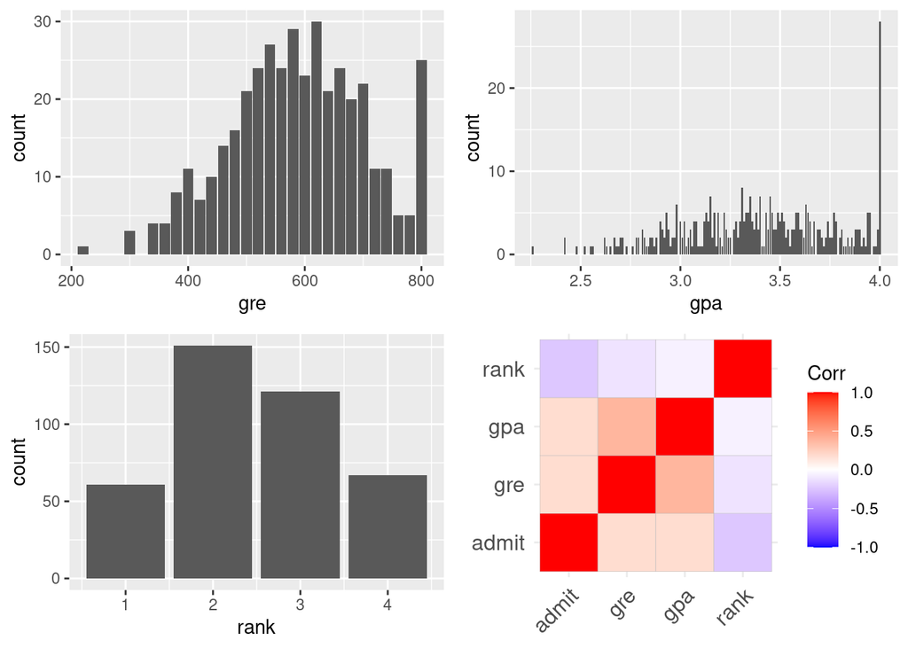

```r
corr <- round(cor(data), 2)
corr_plot <- ggcorrplot(corr)

hist1 = ggplot(data) +
  geom_bar(mapping = aes(x = gre))
hist2 = ggplot(data) +
  geom_bar(mapping = aes(x = gpa))
hist3 = ggplot(data) +
  geom_bar(mapping = aes(x = rank))
ggarrange(hist1, hist2, hist3, corr_plot)
```

Distribution of variables are close to normal distribution, but with large deviations at the end. Also there is low correlation between GPA and GRE.

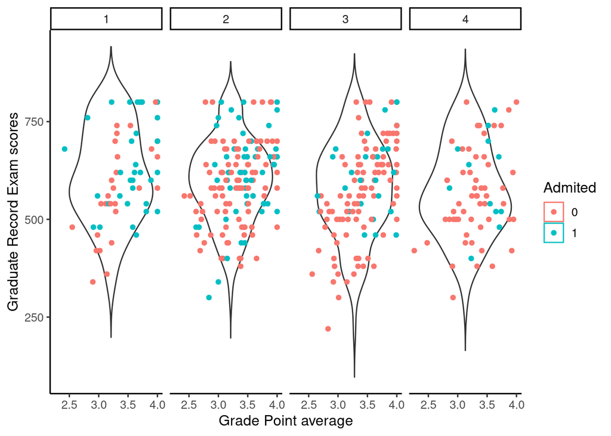

```r
data$admit = as.factor(data$admit)
data$rank = as.factor(data$rank)
ggplot(data, aes(x=gpa, y=gre, group = rank, color = admit))+
  geom_violin(trim = FALSE)+
  geom_point()+
  facet_grid(cols = vars(rank))+
  theme_classic2()+
  ylab('Graduate Record Exam scores')+
  xlab('Grade Point average')+
  labs(color = 'Admited')
```

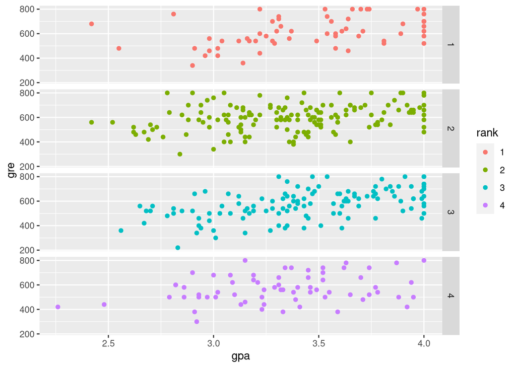

```r
ggplot(data, aes(x = gpa, y = gre, color = rank))+
  geom_point()+
  facet_grid(rows = vars(rank))
```

As I said earlier, there is a correlation between GRE and GPA, but it is not high. Most of the students with the highest scores on one variable do not have the highest scores on the other. Undergraduate institutions with different ranks have the same point grid patterns, but the lowest-ranked higher education institutions have fewer students with the highest GPA scores.

### Log reg model

Let’s analyze the full model first

```r
model_1 <- glm(admit ~., family = 'binomial', data = data)
summary(model_1)
```

```
##
## Call:
## glm(formula = admit ~ ., family = "binomial", data = data)
##
## Deviance Residuals:
##     Min       1Q   Median       3Q      Max
## -1.6268  -0.8662  -0.6388   1.1490   2.0790
##
## Coefficients:
##              Estimate Std. Error z value Pr(>|z|)
## (Intercept) -3.989979   1.139951  -3.500 0.000465 ***
## gre          0.002264   0.001094   2.070 0.038465 *
## gpa          0.804038   0.331819   2.423 0.015388 *
## rank2       -0.675443   0.316490  -2.134 0.032829 *
## rank3       -1.340204   0.345306  -3.881 0.000104 ***
## rank4       -1.551464   0.417832  -3.713 0.000205 ***
## ---
## Signif. codes:  0 '***' 0.001 '**' 0.01 '*' 0.05 '.' 0.1 ' ' 1
##
## (Dispersion parameter for binomial family taken to be 1)
##
##     Null deviance: 499.98  on 399  degrees of freedom
## Residual deviance: 458.52  on 394  degrees of freedom
## AIC: 470.52
##
## Number of Fisher Scoring iterations: 4
```

### Model diagnosis

```r
drop1(model_1, test = "Chi")
```

```
## Single term deletions
##
## Model:
## admit ~ gre + gpa + rank
##        Df Deviance    AIC     LRT  Pr(>Chi)
## <none>      458.52 470.52
## gre     1   462.88 472.88  4.3578   0.03684 *
## gpa     1   464.53 474.53  6.0143   0.01419 *
## rank    3   480.34 486.34 21.8265 7.088e-05 ***
## ---
## Signif. codes:  0 '***' 0.001 '**' 0.01 '*' 0.05 '.' 0.1 ' ' 1
```

As we can see, our complete model is perfect. Removing any of the predictors will reduce the quality of our model and lead to an increase in **AIC**. In this regard, I am using the complete model

### Conditions of model applicability

#### Overdispersion

First lest check overdispersion of our model using function of Ben Bolker (http://bbolker.github.io/mixedmodels-misc/glmmFAQ.html)

Overdispersion ratio are close to 1, so everything is **OK**.

```r
overdisp_fun(model_1)
```

```
##       chisq       ratio         rdf           p
## 397.4901989   1.0088584 394.0000000   0.4412888
```

#### Linearity check

Linear pattern in residuals are **OK**

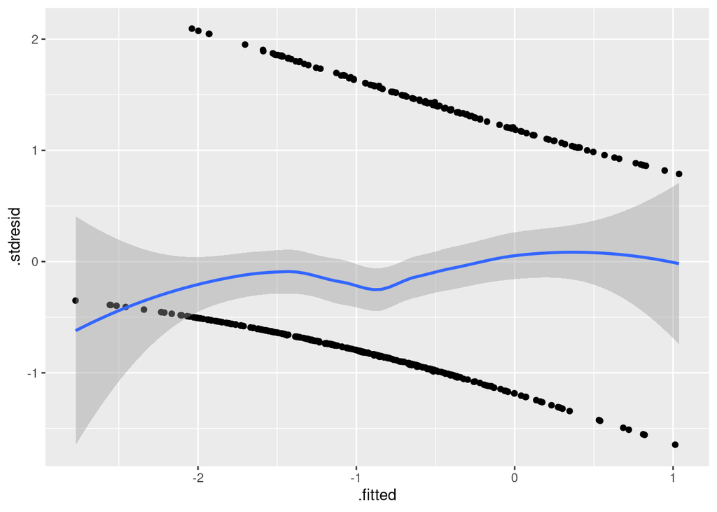

```r
model_1_diag <- fortify(model_1)
ggplot(model_1_diag, aes(x = .fitted, y = .stdresid))+
  geom_point()+
  geom_smooth()
```

### Model prediction

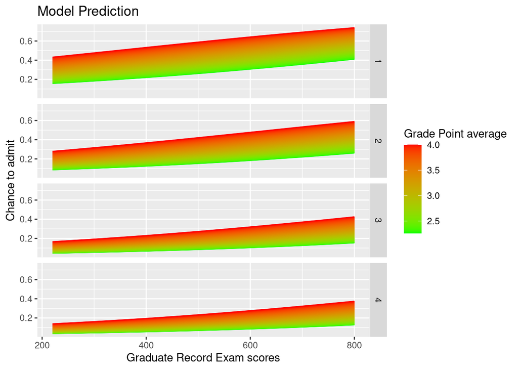

```r
MyData = expand.grid(gpa = seq(min(data$gpa), max(data$gpa), 0.01),
                     gre = seq(min(data$gre), max(data$gre), 10),
                     rank = levels(data$rank))
MyData$Predicted <- predict(model_1, newdata = MyData, type = 'response')

ggplot(MyData, aes(x = gre, y = Predicted, color = gpa, group = gpa))+
  geom_line()+
  facet_grid(rows = vars(rank))+
  scale_color_gradient(low = 'green', high = 'red') +
  xlab('Graduate Record Exam scores')+
  ylab('Chance to admit')+
  labs(color = 'Grade Point average')+
  ggtitle('Model Prediction')
```

Due to our model prediction we can make a conclusion that GRE and GPA scores play significant role in change to admit to the graduate school, but most significant factor is prestige of the undergraduate institution.

**How many times will the probability of enrollment change depending on the rank of the undergraduate institution:**

```
##    rank2
## 0.508931
```

```
##     rank3
## 0.2617923
```

```
##     rank4
## 0.2119375
```

### Conclusion

Points play significant role in admission success, but you need to study in top rank institution for highly increased chances to admit.